# Auto Differentiation and TesnsorFlow

# Why do you care about gradient?

Gradient descent algorithms. Imagine that you need to minimize a function, e.g. $f(x) = x^2$

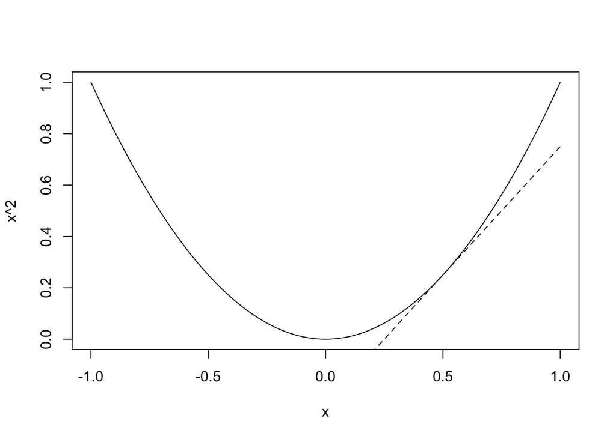

```r
x <- seq(-1, 1, len = 100)
plot(x, x^2, type = "l")
lines(x, (x-0.5) + 0.5^2, type = "l", lty = 2)
```

Suppose the current estimate of the minimizer is 0.5, a gradient descent algorithm asserts that the minimum is in the opposite direction of the slope. Our next estimate would be
$$0.5 - slope * learning rate$$

# What is Automatic Differentiation?

Given a function `f(x)`, which is the derivative of `f(x)` at a given value of `x`?

There are generally, three ways to get the answer

- symbolic differentiation (think of wolfram alpha)
- numeric differentiation

```r
library(numDeriv)
f <- function(x) {
    x^3
}
grad(f, x = 2)
```

```
## [1] 12
```

Behind the scene, it uses finite differencing. Recall the differentiation from first principles

$$f'(x) = \lim_{h -> 0} \frac{f(x+h) - f(x)}{h} \approx \frac{f(x+\delta) - f(x)}{\delta}$$
for same small $\delta$.

```r
delta <- 1e-10
(f(2 + delta) - f(2)) / delta
```

```
## [1] 12
```

It may cause problems if delta is too large or too small.

- automatic differentiation

It is neither symbolic nor numeric differentiaion. It exploits the fact that most functions, no matter how complicated, executes a sequence of elementary arithmetic operations (addition, subtraction, multiplication, division, etc.) and elementary functions (exp, log, sin, cos, etc.)

The exact principles behind AD are beyond the scope of our class (google it if you are interested).

There are a few packages that do AD in R, - madness: automatic differentiation of multivariate operations (forward mode) - cgraph: create, evaluate, and differentiate computational graphs in R (reverse mode) - tensorflow: interface to python package tensorflow (reverse mode) - autodiffr: interface to julia packages ForwardDiff.jl and ReverseDiff.jl

## Forward mode vs reverse mode

Consider the following equation

- `y = z^2`
- `z = x1^2 + x1 * x2`

Find $dy/dx1$ and $dy/dx2$ at `x1=1`, `x2=2`.

## madness

Just to give you a taste:

```r
library(madness)
x <- c(1, 2)
madx <- madness(x)
f <- function(x) {
  z <- x[1]^2 + x[1] * x[2]
  z^2
}
```

```r
f(x)
```

```
## [1] 9
```

```r
(v <- f(madx))
```

```
## class: madness
##         d (((x[...] ^ numeric) + (x[...] * x[...])) ^ numeric)
##  calc: --------------------------------------------------------
##                                   d x
##   val: 9 ...
##  dvdx: 24 6 ...
##  varx:  ...
```

The functional value is 9, while $dy/dx1 = 24$ and $dy/dx2 = 6$.

```r
# value
val(v)
```

```
##      [,1]
## [1,]    9
```

```r
# derivative
dvdx(v)
```

```
##      [,1] [,2]
## [1,]   24    6
```

## cgraph

`cgraph` uses a computaional graph to evaluate derivations of a function.

```r
library(cgraph)

graph <- cg_graph()

x <- cg_input("x")

z <- x[1]^2 +x[1] * x[2]
y <- z^2
```

```r
# forward propagation
x$value <- c(1, 2)
cg_graph_forward(graph, y)
y$value
```

```
## [1] 9
```

```r
# backward propagation
cg_graph_backward(graph, y)
x$grad
```

```
## [1] 24  6
```

## Tensorflow

```r
library(reticulate)
library(tensorflow)
# create an conda env for tensorflow
if (!("r-tensorflow" %in% conda_list()$name)) {
  conda_create("r-tensorflow")
}
use_condaenv("r-tensorflow", required = TRUE)
```

```r
# if tensorflow was not installed
install_tensorflow(envname = "r-tensorflow")
```

In Python

```python
import tensorflow as tf

x = tf.Variable([1.0, 2.0])

with tf.GradientTape() as t:
  t.watch(x)
  z = x[0]**2 + x[0] * x[1]
  y = z**2

dy_dx = t.gradient(y, x)
dy_dx.numpy()
```

```
## array([24.,  6.], dtype=float32)
```

Or with R

```r
x <- tf$Variable(c(1, 2))

with(tf$GradientTape() %as% t, {
  t$watch(x)
  z <- x[1]^2 + x[1] * x[2]
  y <- z ^ 2
})

(dy_dx <- t$gradient(y, x))
```

```
## tf.Tensor([24.  6.], shape=(2,), dtype=float32)
```

```r
dy_dx$numpy()
```

```
## [1] 24  6
```

# What is Tensorflow?

A general purpose numerical computing library.

- Originally developed by researchers and enginners working on the Google Brain Team for the purposes of conducting machine learning and deep nerual networks research.
- Open source
- Hardware independnt
- CPU, GPU or TPU (Tensor processing unit)
- Support automatic differentiation
- Distributed execution

## What are tensors?

| Dimension | R object |
| --- | --- |
| 0D | 42 |
| 1D | c(42, 42, 42) |
| 2D | matrix(42, nc = 2, nr = 2) |
| 3D | array(42, dim = c(2, 3, 2)) |
| 4D | array(42, dim = c(2, 3, 2, 3)) |

Examples

| Data | Tensor |
| --- | --- |
| Vector data | 2D tensors of shape (samples, features) |
| Image data | 4D tensors of shape (samples, height, width, channels) |

Note that `samples` is always the first dimension.

## So What is flowing?

- user define a datagraph in R
- graph is complied and optimized
- graph is executed on devices
- nodes represent computations
- data (tensors) flow between nodes
- automatic differentiation is used to update parameters in the graph

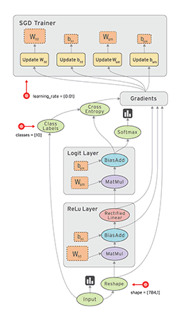